# Sprint 8 : Tasca M8 T01

### Exercici 3

#### Calcula el rendiment del clustering mitjançant un paràmetre com pot ser silhouette.

El método de average silhouette considera como número óptimo de clusters aquel que maximiza la media del silhouette coeficient de todas las observaciones. El silhouette coeficient (si) cuantifica cómo de buena es la asignación que se ha hecho de una observación comparando su similitud con el resto de observaciones de su cluster frente a las de los otros clusters. Su valor puede estar entre -1 y 1, siendo valores próximos a 1 un indicativo de que la observación se ha asignado al cluster correcto.

Para cada observación i , el silhouette coeficient (si) se obtiene del siguiente modo:

- Calcular el promedio de las distancias (llámese ai ) entre la observación i y el resto de observaciones que pertenecen al mismo cluster. Cuanto menor sea ai , mejor ha sido la asignación de i a su cluster.
- Calcular la distancia promedio entre la observación i y el resto de clusters. Entendiendo por distancia promedio entre i y un determinado cluster C como la media de las distancias entre i y las observaciones del cluster C .
- Identificar como bi a la menor de las distancias promedio entre i y el resto de clusters, es decir, la distancia al cluster más próximo (neighbouring cluster).
- Calcular el valor de silhouette como: si= (bi−ai)/max(ai,bi)

Se considera como número óptimo de clusters aquel que maximiza la media del silhouette coeficient de todas las observaciones.

### 3.1 Silhouette - Modelo KMeans

```python
from sklearn.metrics import silhouette_score
kmeans_silhouette = silhouette_score(df_pca, k_means.labels_).round(5)
```

```python
kmeans_silhouette
```

```
0.88853
```

```python
data.head(3)
```

|  | status_type | num_reactions | num_comments | num_shares | num_likes | num_loves | num_wows | num_hahas | num_sads | num_angrys | Cluster |
| --- | --- | --- | --- | --- | --- | --- | --- | --- | --- | --- | --- |
| 0 | 3 | 2.324257 | 22.086957 | 65.50 | 2.229508 | 30.666667 | 3.0 | 1.0 | 1.0 | 0.0 | 1 |
| 1 | 1 | 0.448020 | -0.173913 | 0.00 | 0.548435 | 0.000000 | 0.0 | 0.0 | 0.0 | 0.0 | 2 |
| 2 | 3 | 0.829208 | 10.086957 | 14.25 | 0.870343 | 7.000000 | 1.0 | 1.0 | 0.0 | 0.0 | 3 |

```python
from sklearn.cluster import KMeans
from sklearn.metrics import silhouette_score

# A list holds the silhouette coefficients for each k
silhouette_coefficients = []

# silhouette starts at 2 clusters!!
for k in range(2,11):
    kmeans = KMeans(n_clusters= k, random_state=1)
    kmeans.fit(X) #data.drop(['status_type'],axis=1))
    score = silhouette_score(df_pca, kmeans.labels_)
    silhouette_coefficients.append(score)
```

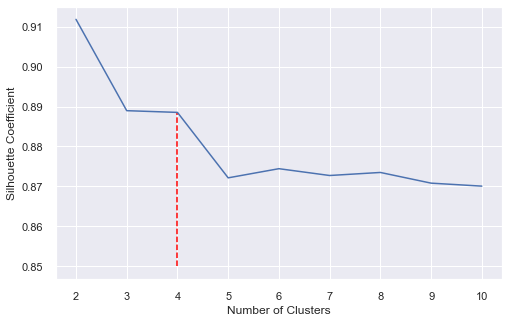

```python
# plot the previous result
plt.plot(range(2, 11), silhouette_coefficients)
plt.xticks(range(2, 11))
plt.xlabel("Number of Clusters")
plt.ylabel("Silhouette Coefficient")
plt.vlines(x= 4, ymax = 0.88853, ymin= 0.85,  color = 'red', linestyles = '--')
plt.grid(True)
plt.show()
```

- La gráfica del coeficiente de Silhouette indica que el número óptimo de clúster es 2 con un coeficiente de 0.91, por tanto superior al que hemos utiizado en nuesto modelo que ha sido de 4 clústers.
- Según la gráfica no existe diferencia en cuanto al valor del coeficiente Silhouette si en el modelo se calcula con 3 ó 4 clusters.

### 3.2 Silhouette - KMedoids

```python
kmed_silhouette = silhouette_score(df2_pca,kmedoids.labels_).round(5)
kmed_silhouette
```

```
0.55464
```

- El resultado del coeficiente silhouette es particularmente bajo en este caso, ya que para la valoración del mismo hemos asignado 4 clusters para poder comparar con el modelo Kmeans.
- Vamos a evaluar cómo se comporta el coeficinete de silhoutte para estimar el óptimo de clusters que optimizan el modelo Kmedoids.

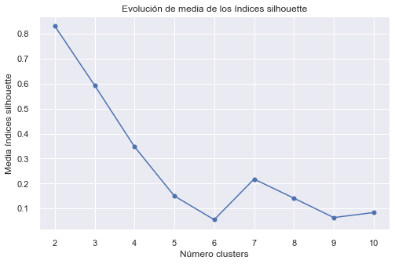

```python
# Método silhouette para identificar el número óptimo de clusters
# ==============================================================================
range_n_clusters = range(2, 11)
valores_medios_silhouette = []

for n_clusters in range_n_clusters:
    modelo = KMedoids(n_clusters=n_clusters, random_state=1)
    cluster_labels = modelo.fit_predict(X)
    silhouette_avg = silhouette_score(X, cluster_labels)
    valores_medios_silhouette.append(silhouette_avg)

fig, ax = plt.subplots(1, 1, figsize=(8, 5))
ax.plot(range_n_clusters, valores_medios_silhouette, marker='o')
ax.set_title("Evolución de media de los índices silhouette")
ax.set_xlabel('Número clusters')
ax.set_ylabel('Media índices silhouette');
```

- Como en el caso anterior el número optimo de clusters es 2 y el valor del coeficiente silhouette se sitúa en 0.8

### 3.3 Silhouette - Modelo AgglomerativeClustering

```python
agglo_silhouette = silhouette_score(df_pca_agg, agglo.labels_).round(5)
agglo_silhouette
```

```
0.87408
```

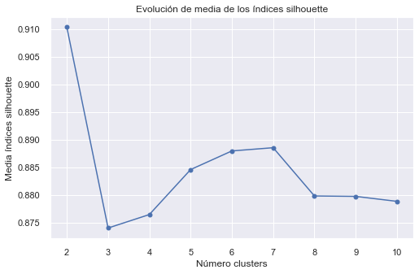

```python
# Método silhouette para identificar el número óptimo de clusters
# ==============================================================================
range_n_clusters = range(2, 11)
valores_medios_silhouette = []

for n_clusters in range_n_clusters:
    modelo = AgglomerativeClustering(n_clusters = n_clusters, affinity = "euclidean", linkage = "ward")

    cluster_labels = modelo.fit_predict(df_pca_agg)
    silhouette_avg = silhouette_score(df_pca_agg, cluster_labels)
    valores_medios_silhouette.append(silhouette_avg)

fig, ax = plt.subplots(1, 1, figsize=(8, 5))
ax.plot(range_n_clusters, valores_medios_silhouette, marker='o')
ax.set_title("Evolución de media de los índices silhouette")
ax.set_xlabel('Número clusters')
ax.set_ylabel('Media índices silhouette');
```

- Como en los dos casos anteriores el óptimo de custers en función del coeficiente silhouette es de 2, con un valor máximo de 0.91.
- El valor de silhouette decrece hasta 3 clusters, para volver a crecer hasta alcanzar un nuevo máximo en 7 cluster con un valor de silhouette de 0.888.

### 3.4 Gráfico de valores de Silhouette con Yellowbrick

```python
from yellowbrick.cluster import SilhouetteVisualizer
```

```
silhouette scores for k clusters:
2 : 0.912
3 : 0.894
4 : 0.893
5 : 0.894
6 : 0.894
7 : 0.886
maximum silhouette score for 2 clusters:  0.912
```

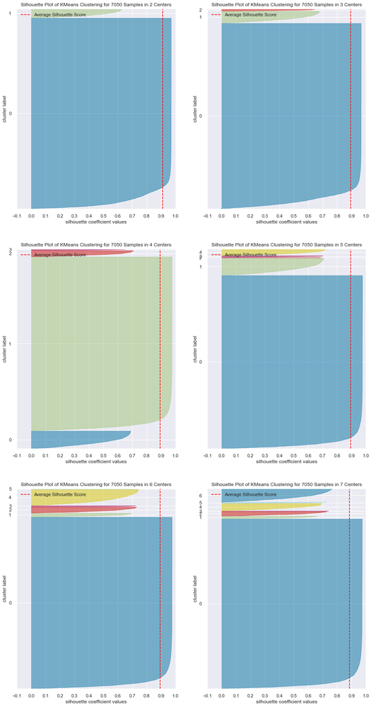

```python
# silhouette score plots with Yellowbrick
dict_score = dict()
fig, ax = plt.subplots(3, 2, figsize=(15,30))

for i in range(2,8):
    km = KMeans(n_clusters=i, random_state=1)

    q, mod = divmod(i, 2)
    vis = SilhouetteVisualizer(km, colors='yellowbrick', ax=ax[q-1][mod], is_fitted=False)
    vis.fit(df_pca)
    vis.finalize()
    dict_score[i] = vis.silhouette_score_

print("silhouette scores for k clusters:")
_ = [print(k,":",f'{v:.3f}') for k,v in dict_score.items()]

K_sil_a3 = max(dict_score, key=dict_score.get)          # optimal clusters
sil_opt_a3 = dict_score[K_sil_a3]                       # optimal (maximal) silhouette score
print("maximum silhouette score for", f'{K_sil_a3:.0f} clusters: ', f'{sil_opt_a3:.3f}')
```

- Los datos obtenidos con la esta libreria son similares a los calculados en apartados anteriores con el modelo KMeans, y el óptimo corresponde a la evaluación con 2 clusters con un valor de 0.912 similar a los datos otenidos en apartados anteriores.
- Existe un factor diferencial cuando calcula k=4 (clusters) ya que agrupa el mayor número de datos en el cluster 1, a diferencia de nuesto análisis que los concentraba en el cluster 0, y del resto de gráficos del propio Yellowbrick que para todos los k!=4, los acumula en el cluster 0.